# midterm2_code2

Ang_Gavrila

3/2/2022

response variable = monocytes (count, discrete) predictor variables = hdl_cholesterol (count, discrete), age (count, continuous) confounding variable = sex (categorical) random variable = cohort (categorical)

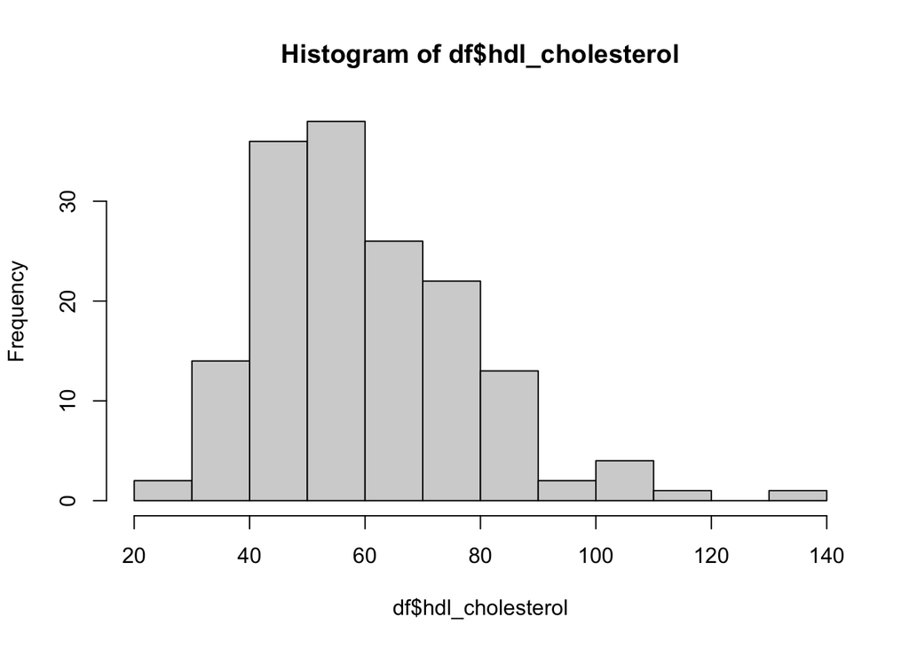

```r
hist(df$hdl_cholesterol) #right-skewed
```

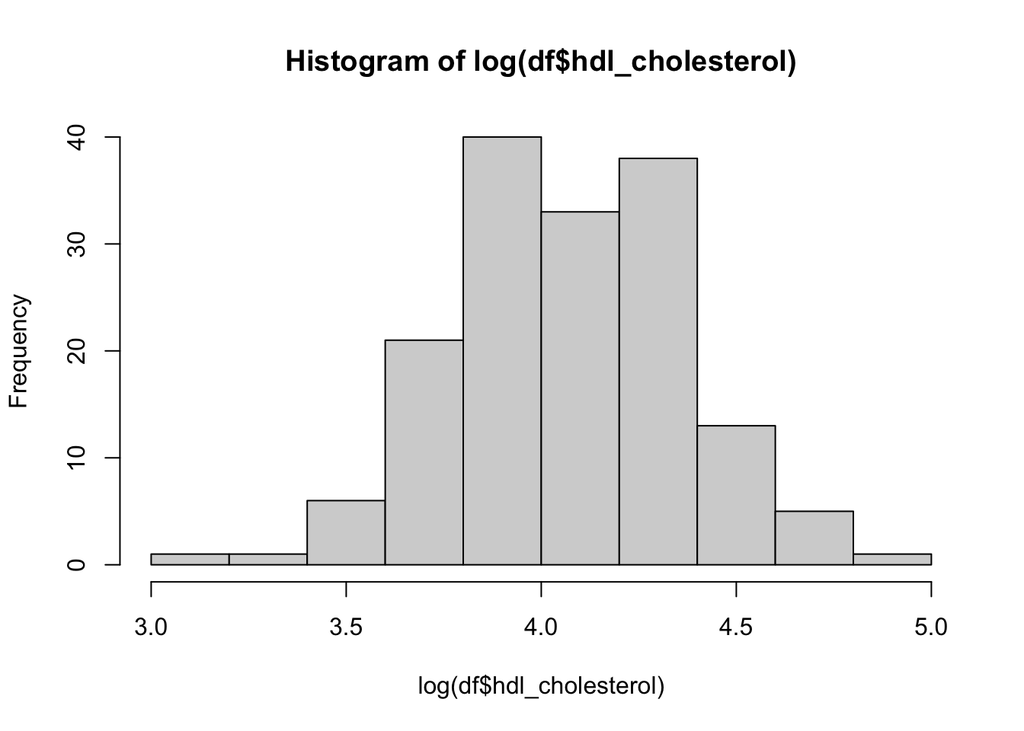

```r
hist(log(df$hdl_cholesterol)) #looks better
```

```r
shapiro.test(log(df$hdl_cholesterol)) #normalised
```

```
##
##  Shapiro-Wilk normality test
##
## data:  log(df$hdl_cholesterol)
## W = 0.99602, p-value = 0.9489
```

Linear Mixed Model Assumptions The explanatory variables are related linearly to the response. (the literature says so) The errors have constant variance. (plot0) The errors are independent. (each observation is independent) The errors are normally distributed. (Q-Q plot)

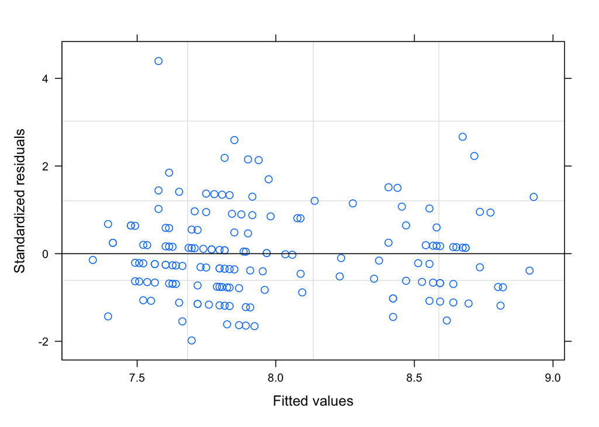

```r
mod0 <- lme(monocytes ~ log(hdl_cholesterol) + sex, random = ~1|cohort, data = df, method = "ML", na.action = na.omit)
plot(mod0)  # the errors have constant variance
```

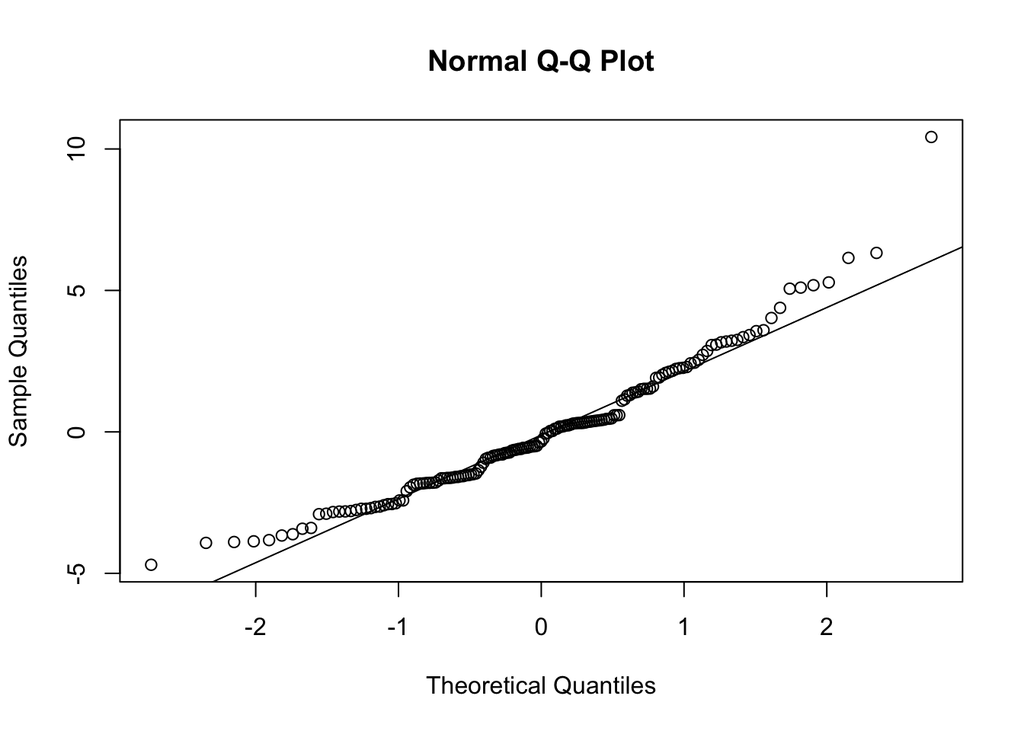

```r
qqnorm(resid(mod0))
qqline(resid(mod0)) # the errors are normally distirbuted
```

```r
Anova(mod0, type = 2) # monocytes is significantly associated with sex
```

```
## Analysis of Deviance Table (Type II tests)
##
## Response: monocytes
##                       Chisq Df Pr(>Chisq)
## log(hdl_cholesterol) 0.8617  1    0.35326
## sex                  4.9262  1    0.02645 *
## ---
## Signif. codes:  0 '***' 0.001 '**' 0.01 '*' 0.05 '.' 0.1 ' ' 1
```

```r
summary(mod0)   # cohort exerts a small random effect onto the model; sex does have a significant contribution to the model
```

```
## Linear mixed-effects model fit by maximum likelihood
##   Data: df
##        AIC      BIC    logLik
##   735.8078 751.1523 -362.9039
##
## Random effects:
##  Formula: ~1 | cohort
##          (Intercept) Residual
## StdDev: 0.0001292081 2.371389
##
## Fixed effects:  monocytes ~ log(hdl_cholesterol) + sex
##                         Value Std.Error  DF   t-value p-value
## (Intercept)          5.129705 2.8489982 142 1.8005295  0.0739
## log(hdl_cholesterol) 0.632165 0.6875140 142 0.9194942  0.3594
## sexMale              0.977381 0.4445735 142 2.1984691  0.0295
##  Correlation:
##                      (Intr) lg(h_)
## log(hdl_cholesterol) -0.997
## sexMale              -0.392  0.352
##
## Standardized Within-Group Residuals:
##        Min         Q1        Med         Q3        Max
## -1.9805165 -0.6888639 -0.1434077  0.5939807  4.3953374
##
## Number of Observations: 159
## Number of Groups: 15
```

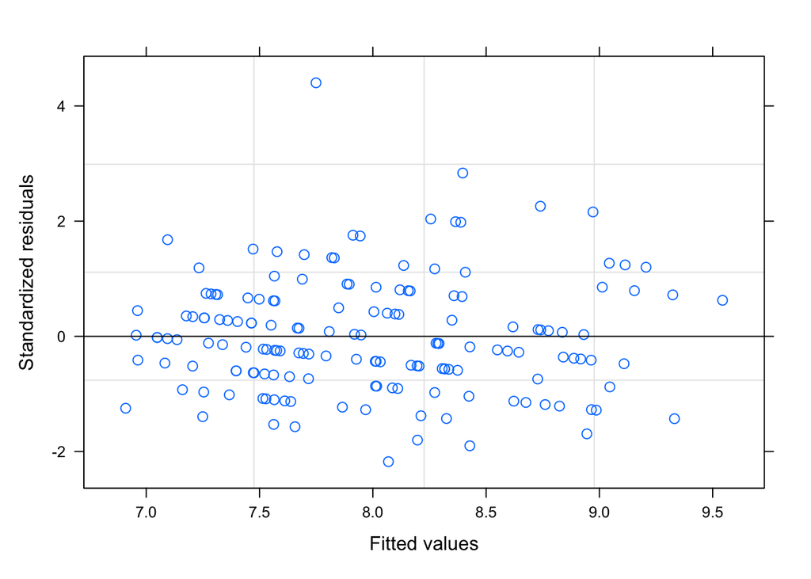

```r
mod1 <- lme(monocytes ~ log(hdl_cholesterol) + age + sex, random = ~1|cohort, data = df, method = "ML", na.action = na.omit)
plot(mod1)  # the errors have constant variance
```

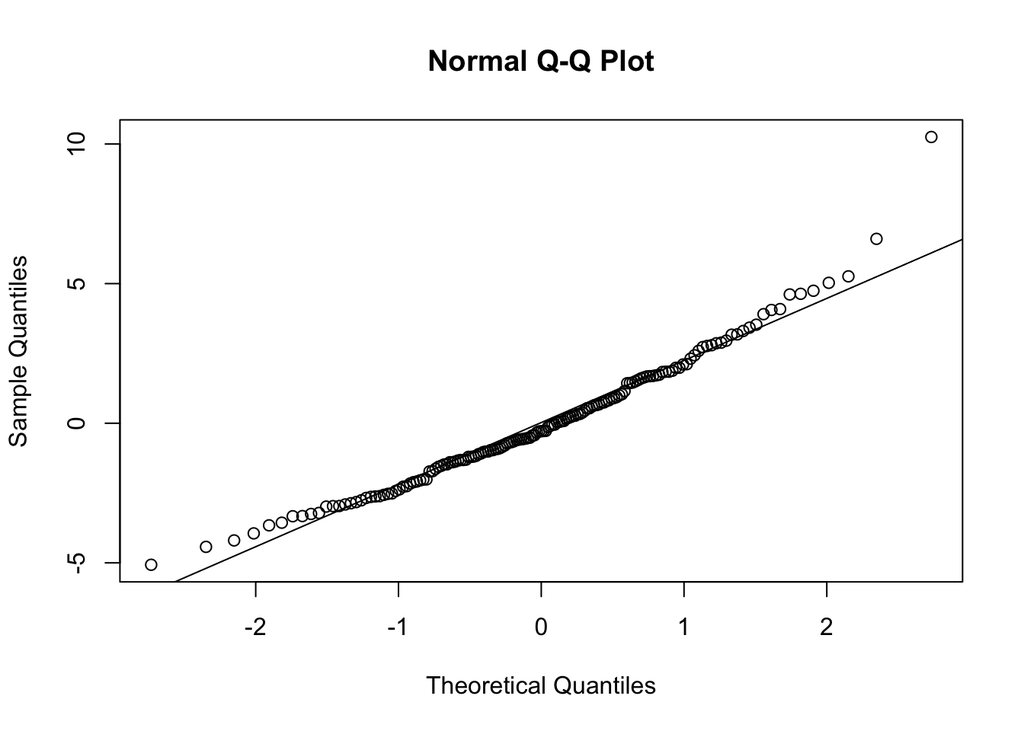

```r
qqnorm(resid(mod1))
qqline(resid(mod1)) # the errors are even more normally distributed!
```

```r
Anova(mod1, type = 2) # monocytes is significantly associated with sex and age
```

```
## Analysis of Deviance Table (Type II tests)
##
## Response: monocytes
##                       Chisq Df Pr(>Chisq)
## log(hdl_cholesterol) 0.2506  1    0.61663
## age                  5.8484  1    0.01559 *
## sex                  4.8360  1    0.02787 *
## ---
## Signif. codes:  0 '***' 0.001 '**' 0.01 '*' 0.05 '.' 0.1 ' ' 1
```

```r
summary(mod1) # cohort exerts a small random effect onto the model; sex and age do have significant contributions to the model. None of the predictor variables are highly correlated to each other.
```

```
## Linear mixed-effects model fit by maximum likelihood
##   Data: df
##        AIC      BIC    logLik
##   732.0644 750.4778 -360.0322
##
## Random effects:
##  Formula: ~1 | cohort
##          (Intercept) Residual
## StdDev: 0.0001067637 2.328944
##
## Fixed effects:  monocytes ~ log(hdl_cholesterol) + age + sex
##                          Value Std.Error  DF   t-value p-value
## (Intercept)          2.0323894 3.0922496 141 0.6572527  0.5121
## log(hdl_cholesterol) 0.3402411 0.6883276 141 0.4943010  0.6219
## age                  0.0593750 0.0248667 141 2.3877335  0.0183
## sexMale              0.9513485 0.4381580 141 2.1712453  0.0316
##  Correlation:
##                      (Intr) lg(h_) age
## log(hdl_cholesterol) -0.816
## age                  -0.419 -0.178
## sexMale              -0.345  0.351 -0.025
##
## Standardized Within-Group Residuals:
##        Min         Q1        Med         Q3        Max
## -2.1764886 -0.6329020 -0.1231755  0.6554470  4.4014712
##
## Number of Observations: 159
## Number of Groups: 15
```

```r
anova(mod0, mod1) #Significantly different, the inclusion of age creates a better model to fit the data.
```

```
##      Model df      AIC      BIC    logLik   Test  L.Ratio p-value
## mod0     1  5 735.8078 751.1523 -362.9039
## mod1     2  6 732.0644 750.4778 -360.0322 1 vs 2 5.743408  0.0166
```

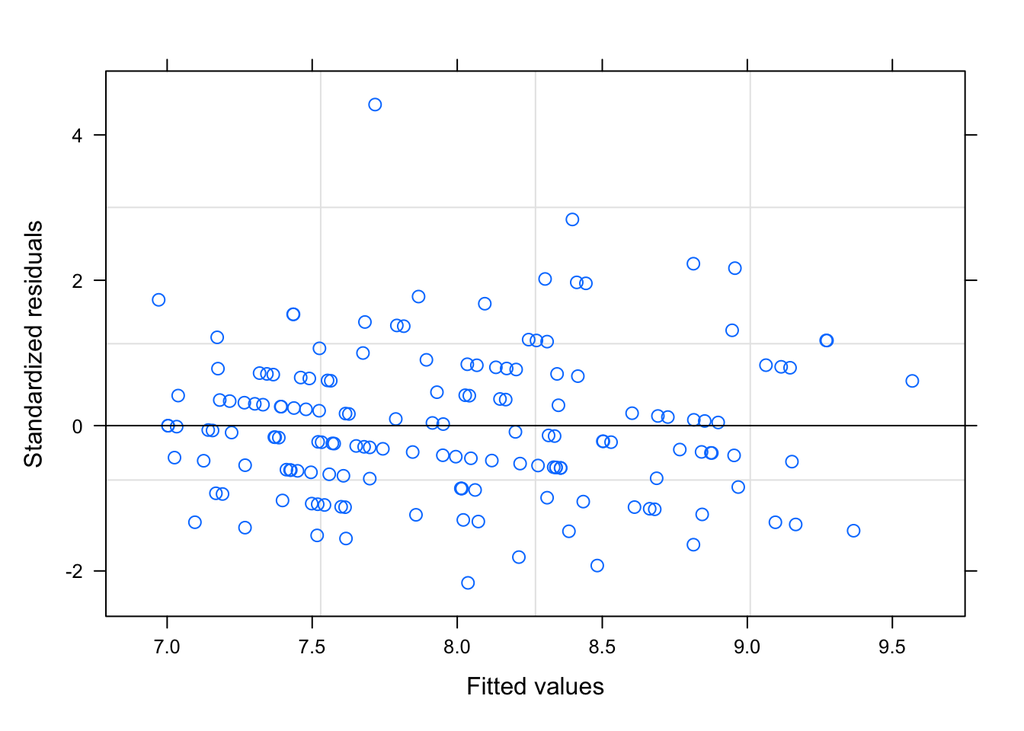

```r
#Could be a reinforcement interaction effect, the effect of cholesterol on monocytes maybe strengthened by age
mod2 <- lme(monocytes ~ log(hdl_cholesterol) * age + sex, random = ~1|cohort, data = df, method = "ML", na.action = na.omit)
plot(mod2) # the errors have constant variance
```

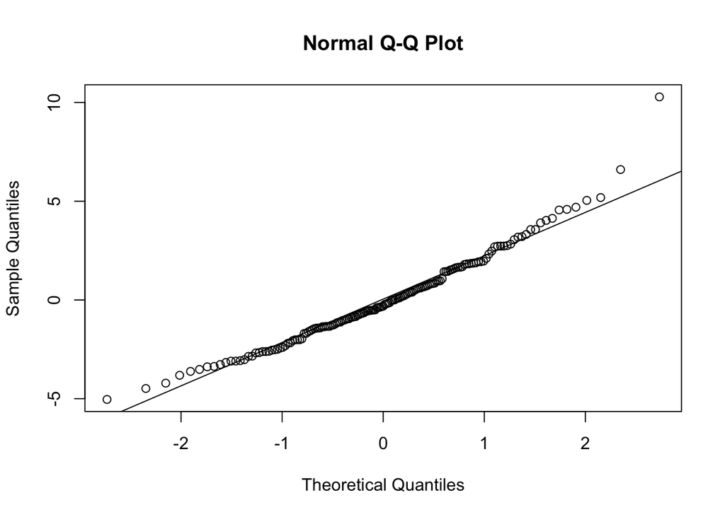

```r
qqnorm(resid(mod2))
qqline(resid(mod2)) # the errors are also every normally distributed!
```

```r
Anova(mod2, type = 3) # monocytes is significantly associated with sex, but hdl_cholesterol and age do not exert an interaction effect. Therefore, only their main effects will be considered.
```

```
## Analysis of Deviance Table (Type III tests)
##
## Response: monocytes
##                           Chisq Df Pr(>Chisq)
## (Intercept)              0.2439  1    0.62138
## log(hdl_cholesterol)     0.1261  1    0.72253
## age                      0.0575  1    0.81053
## sex                      4.8659  1    0.02739 *
## log(hdl_cholesterol):age 0.1721  1    0.67828
## ---
## Signif. codes:  0 '***' 0.001 '**' 0.01 '*' 0.05 '.' 0.1 ' ' 1
```

```r
summary(mod2)  # cohort exerts a small random effect onto the model; sex continues to have a significant contribution to the model.
```

```
## Linear mixed-effects model fit by maximum likelihood
##   Data: df
##        AIC      BIC    logLik
##   733.8924 755.3748 -359.9462
##
## Random effects:
##  Formula: ~1 | cohort
##          (Intercept) Residual
## StdDev: 0.0001053432 2.327685
##
## Fixed effects:  monocytes ~ log(hdl_cholesterol) * age + sex
##                              Value Std.Error  DF    t-value p-value
## (Intercept)              12.203004 25.105448 140  0.4860700  0.6277
## log(hdl_cholesterol)     -2.118180  6.061403 140 -0.3494537  0.7273
## age                      -0.081809  0.346733 140 -0.2359430  0.8138
## sexMale                   0.953871  0.439384 140  2.1709275  0.0316
## log(hdl_cholesterol):age  0.034079  0.083478 140  0.4082412  0.6837
##  Correlation:
##                          (Intr) lg(h_) age    sexMal
## log(hdl_cholesterol)     -0.997
## age                      -0.994  0.989
## sexMale                  -0.029  0.026 -0.016
## log(hdl_cholesterol):age  0.992 -0.993 -0.997  0.014
##
## Standardized Within-Group Residuals:
##        Min         Q1        Med         Q3        Max
## -2.1639851 -0.6177264 -0.1352593  0.6550297  4.4177785
##
## Number of Observations: 159
## Number of Groups: 15
```

```r
anova(mod1, mod2) #Not significantly different, the inclusion of an interaction term does not result in a better model fit.
```

```
##      Model df      AIC      BIC    logLik   Test   L.Ratio p-value
## mod1     1  6 732.0644 750.4778 -360.0322
## mod2     2  7 733.8924 755.3748 -359.9462 1 vs 2 0.1719789  0.6784
```

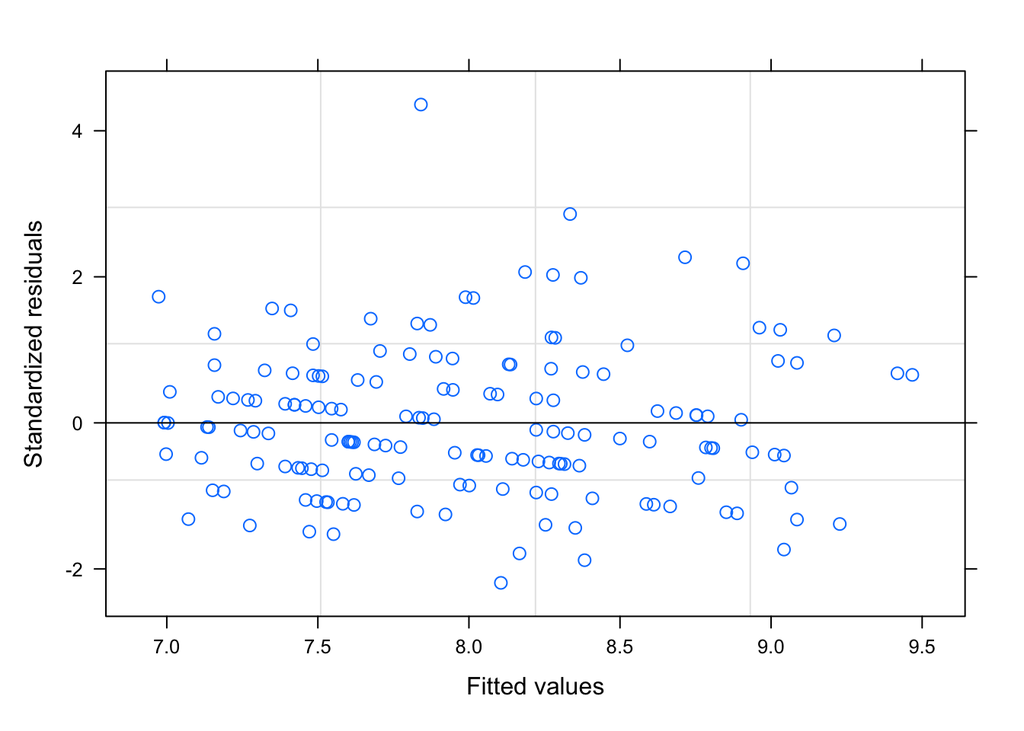

```r
#hdl_cholesterol does not seem to predict monocyte count very well; let's exclude it.
mod3 <- lme(monocytes ~ age + sex, random = ~1|cohort, data = df, method = "ML", na.action = na.omit)
plot(mod3)  # the errors have constant variance
```

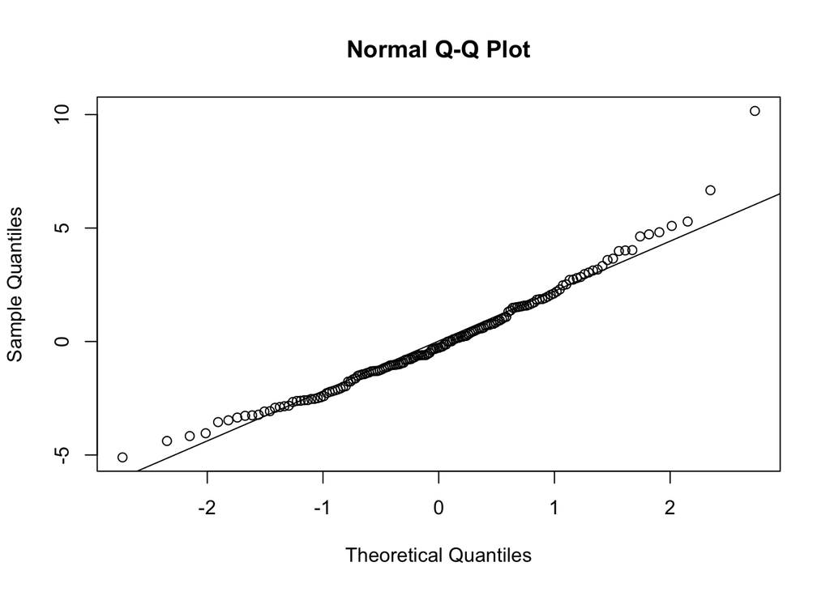

```r
qqnorm(resid(mod3))
qqline(resid(mod3)) # the errors are even more normally distributed!
```

```r
Anova(mod3, type = 2) # monocytes is significantly associated with sex and age
```

```
## Analysis of Deviance Table (Type II tests)
##
## Response: monocytes
##      Chisq Df Pr(>Chisq)
## age 6.4810  1    0.01090 *
## sex 4.6618  1    0.03084 *
## ---
## Signif. codes:  0 '***' 0.001 '**' 0.01 '*' 0.05 '.' 0.1 ' ' 1
```

```r
summary(mod3) # cohort exerts a small random effect onto the model; sex and age do have significant contributions to the model. None of the predictor variables are highly correlated to each other, as expected since age does not determine sex
```

```
## Linear mixed-effects model fit by maximum likelihood
##   Data: df
##        AIC      BIC    logLik
##   730.3149 745.6594 -360.1574
##
## Random effects:
##  Formula: ~1 | cohort
##          (Intercept) Residual
## StdDev: 0.0001072882 2.330779
##
## Fixed effects:  monocytes ~ age + sex
##                Value Std.Error  DF  t-value p-value
## (Intercept) 3.279638 1.7831724 142 1.839215  0.0680
## age         0.061558 0.0244119 142 2.521644  0.0128
## sexMale     0.875341 0.4092955 142 2.138654  0.0342
##  Correlation:
##         (Intr) age
## age     -0.992
## sexMale -0.108  0.041
##
## Standardized Within-Group Residuals:
##        Min         Q1        Med         Q3        Max
## -2.1905998 -0.6274814 -0.1198661  0.6464364  4.3585842
##
## Number of Observations: 159
## Number of Groups: 15
```

```r
anova(mod1, mod3) #Not significantly different, and so the inclusion of hdl_cholesterol isn't contributing to the model fit and therefore can be removed
```

```
##      Model df      AIC      BIC    logLik   Test   L.Ratio p-value
## mod1     1  6 732.0644 750.4778 -360.0322
## mod3     2  5 730.3149 745.6594 -360.1574 1 vs 2 0.2504416  0.6168
```

Conclusion: mod3 is the best model to fit the clinical data.

Sex is a fixed effect as it does not change at a constant rate over time. Sex is a confounding variable (as seen in the previous presentation) and was controlled for. Previous studies have shown postmenopausal women have higher hdl_cholesterol than men of the same age. As such, sex affects both the independent variable (hdl_cholesterol) and the dependent variable.

subjects were placed into cohorts that completed the intervention at different times and places. The creation of cohorts may have lead to “group effects”; this will be accounted for by including the cohort variable as a random effect. Interestingly, cohort only exerts a small random effect onto the model.

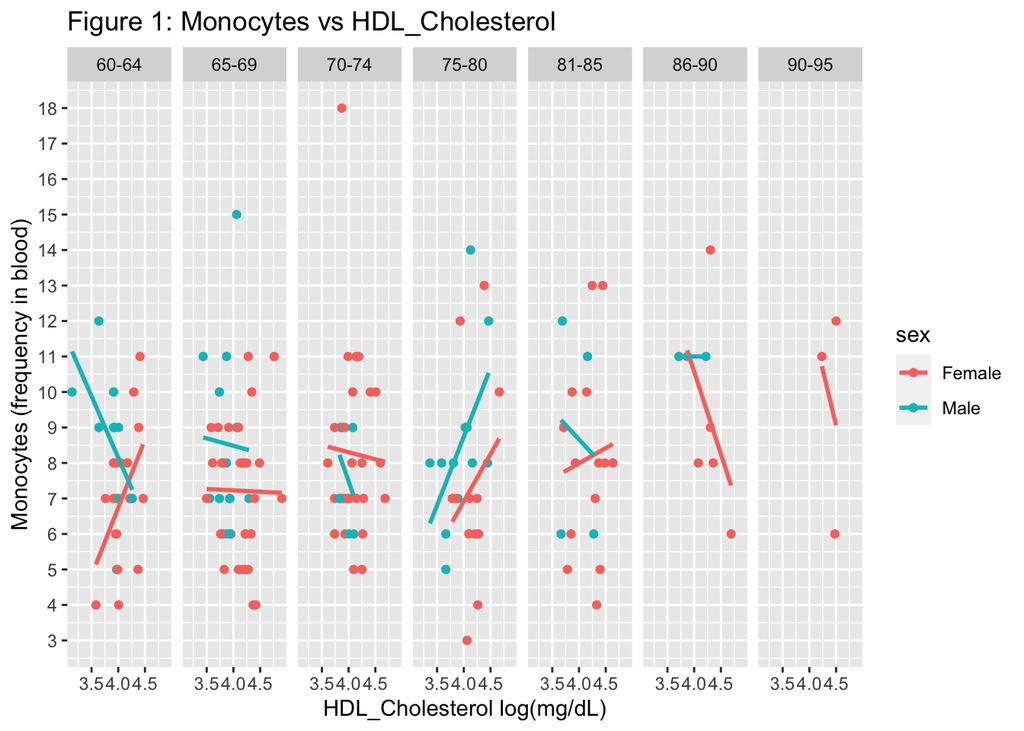

```r
#Plot taking into consideration all the variables initially considered
ggplot(data = df, aes(x = log(hdl_cholesterol), y = monocytes, colour = sex)) +
  geom_point() +
  geom_smooth(method = 'lm', se=FALSE) +
  facet_grid(.~agebin) +
  scale_y_continuous(n.breaks = 20) + # make more breaks on the y-axis
  ylab("Monocytes (frequency in blood)") +
  xlab("HDL_Cholesterol log(mg/dL)") +
  ggtitle("Figure 1: Monocytes vs HDL_Cholesterol")
```

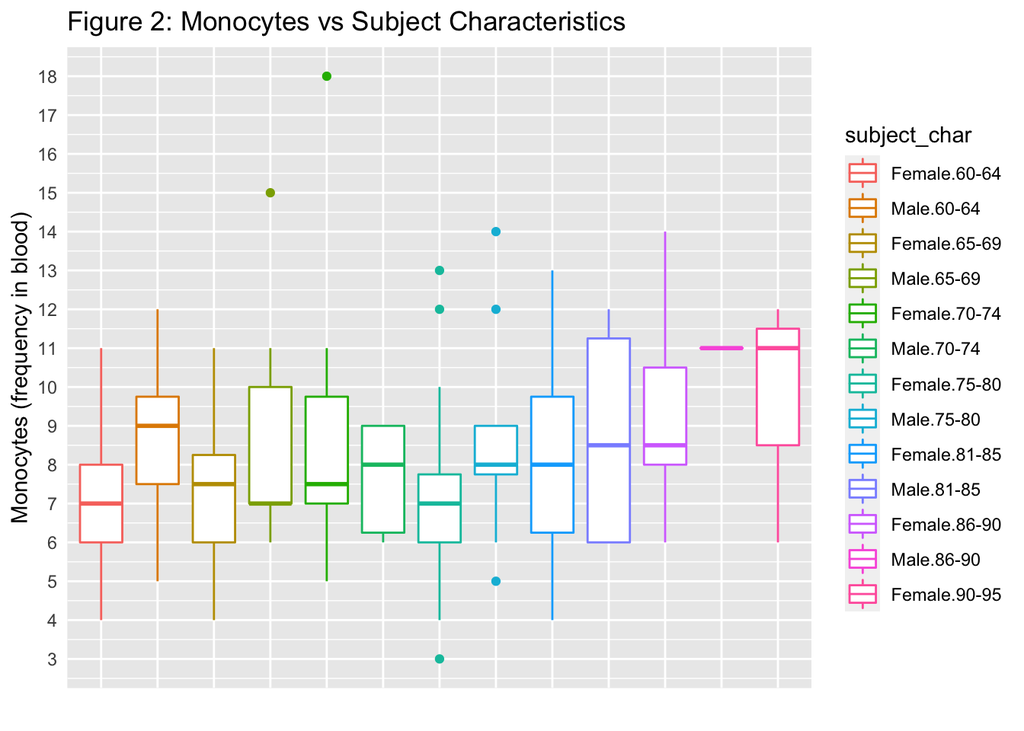

```r
#Plot taking into consideration, only the variables that significantly affect monocyte count in the clinical population
df$subject_char <- interaction(df$sex, df$agebin)
ggplot(data = df, aes(x=subject_char, y= monocytes, colour = subject_char)) +
  geom_boxplot() +
  theme(axis.ticks = element_blank(), # remove x-axis tick marks
        axis.text.x = element_blank()) + # remove x-axis labels because it is in the legend
  scale_y_continuous(n.breaks = 20) + # make more breaks on the y-axis
  ylab("Monocytes (frequency in blood)") +
  xlab("") +
  ggtitle("Figure 2: Monocytes vs Subject Characteristics")
```